# InformeProyecto1

```
## *** : The Hubert index is a graphical method of determining the number of clusters.
##                 In the plot of Hubert index, we seek a significant knee that corresponds to a
##                 significant increase of the value of the measure i.e the significant peak in Hubert
##                 index second differences plot.
##
```

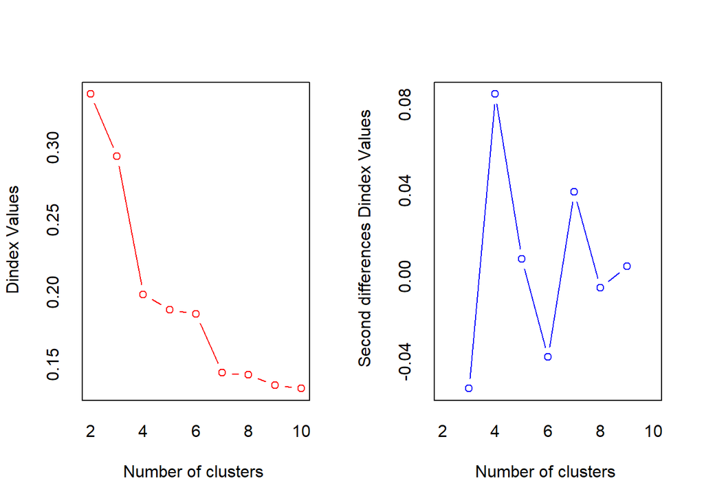

```
## *** : The D index is a graphical method of determining the number of clusters.
##                 In the plot of D index, we seek a significant knee (the significant peak in Dindex
##                 second differences plot) that corresponds to a significant increase of the value of
##                 the measure.
##
## * Among all indices:
## * 3 proposed 2 as the best number of clusters
## * 14 proposed 3 as the best number of clusters
## * 4 proposed 4 as the best number of clusters
## * 2 proposed 7 as the best number of clusters
##
##                    ***** Conclusion *****
##
## * According to the majority rule, the best number of clusters is  3
##
##
```

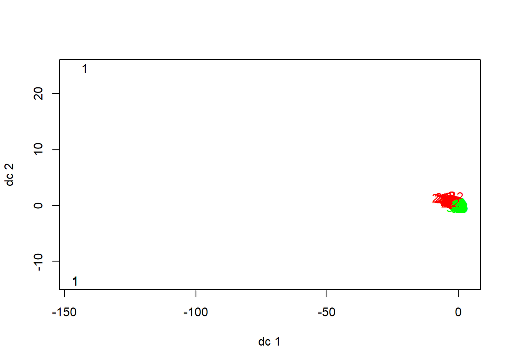

```r
km<-kmeans(datos[,6:7],3)
datos$grupo<-km$cluster

plotcluster(datos[,6:7],km$cluster)
```

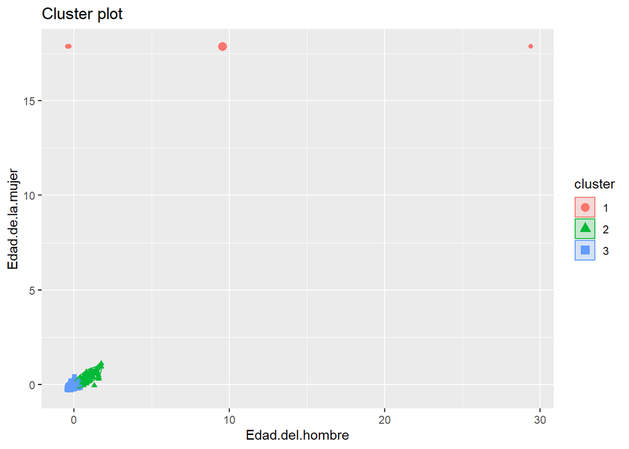

```r
fviz_cluster(km, data = datos[,6:7],geom = "point", ellipse.type = "norm")
```

Como se puede observar en las graficas anterior tenemos 3 clusters o centroides que ayudan a distribuir los datos. Para medir la calidad de esto utilizamos el metodo de la silueta.

```r
#Metodo de silueta
silkm<-silhouette(km$cluster,dist(datos[,6:7]))
mean(silkm[,3])
```

```
## [1] 0.7309132
```

el cual nos dio un valor cercano a 1 indicando que el agrupamiento tiene buena calidad.

## Conclusiones:

1. Se determino que, a pesar de las leyes impuestas por el gobierno sobre la prohibición del matrimonio entre menores, si disminuyo conforme el tiempo, sin embargo, esto no significa que ya no existan uniones con algún menor de edad.
2. Además, se demuestra que el departamento de Guatemala tiene mayor cantidad de registros, esto puede ser causado porque las personas de otros departamentos vienen a este departamento a realizar su unión.